# Exercises

### 9.e

From the correlation table we can see that there is strong indication of correlation between cylinders, displacement, acceleration, and weight. We will use these predictors as interactions.

```r
fit3=lm(formula = mpg ~ . + displacement * acceleration * cylinders * weight * horsepower - name, data = Auto)
summary(fit3)
```

```
##
## Call:
## lm(formula = mpg ~ . + displacement * acceleration * cylinders *
##     weight * horsepower - name, data = Auto)
##
## Residuals:
##     Min      1Q  Median      3Q     Max
## -7.8560 -1.4192  0.0024  1.3975 12.5339
##
## Coefficients:
##                                                         Estimate
## (Intercept)                                            1.329e+02
## cylinders                                             -3.008e+01
## displacement                                           1.843e+00
## horsepower                                            -4.051e+00
## weight                                                -1.284e-01
## acceleration                                          -2.481e+01
## year                                                   7.467e-01
## origin                                                 7.128e-01
## displacement:acceleration                             -5.660e-02
## cylinders:displacement                                -2.363e-01
## cylinders:acceleration                                 5.363e+00
## displacement:weight                                   -3.014e-06
## weight:acceleration                                    1.281e-02
## cylinders:weight                                       1.677e-02
## displacement:horsepower                               -1.329e-03
## horsepower:acceleration                                4.217e-01
## cylinders:horsepower                                   8.610e-01
## horsepower:weight                                      1.778e-03
## cylinders:displacement:acceleration                    2.958e-03
## displacement:weight:acceleration                      -2.142e-05
## cylinders:displacement:weight                          3.617e-06
## cylinders:weight:acceleration                         -2.074e-03
## displacement:horsepower:acceleration                  -5.689e-04
## cylinders:displacement:horsepower                     -6.377e-04
## cylinders:horsepower:acceleration                     -9.099e-02
## displacement:horsepower:weight                        -3.833e-06
## horsepower:weight:acceleration                        -1.677e-04
## cylinders:horsepower:weight                           -2.972e-04
## cylinders:displacement:weight:acceleration             3.621e-06
```

[output cut: 66 more lines]

```
## displacement:horsepower:weight                         0.71099
## horsepower:weight:acceleration                         0.05520 .
## cylinders:horsepower:weight                            0.16030
## cylinders:displacement:weight:acceleration             0.63525
## cylinders:displacement:horsepower:acceleration         0.52623
## displacement:horsepower:weight:acceleration            0.42985
## cylinders:displacement:horsepower:weight               0.62162
## cylinders:horsepower:weight:acceleration               0.02404 *
## cylinders:displacement:horsepower:weight:acceleration  0.29871
## ---
## Signif. codes:  0 '***' 0.001 '**' 0.01 '*' 0.05 '.' 0.1 ' ' 1
##
## Residual standard error: 2.707 on 358 degrees of freedom
## Multiple R-squared:  0.8899, Adjusted R-squared:  0.8797
## F-statistic: 87.67 on 33 and 358 DF,  p-value: < 2.2e-16
```

Acceleration and horsepower have the greatest interaction. Our R-squared values improved by using this model. Let’s examine the residuals vs fitted value graph.

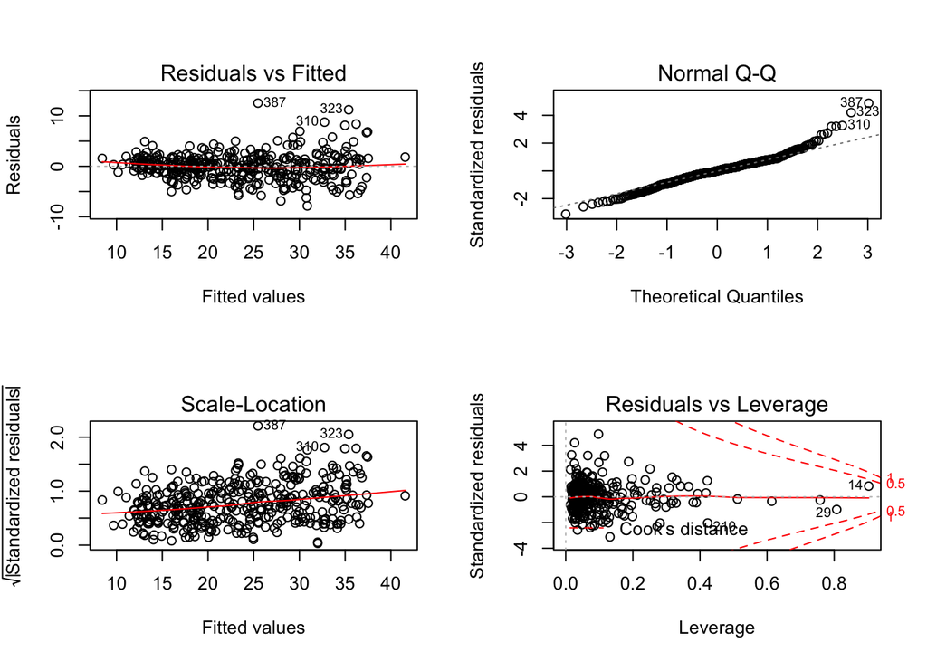

```r
par(mfrow=c(2,2))
plot(fit3)
```

There does not seem to be any noticable pattern in the residuals vs fitted graph suggesting the correlation fits the data. However, a funnel shape is present in the residual graph which is a sign of heteroscedasticity, meaning the magnitude of residuals tends to increase with the fitted values.

### 9.f

Because of heteroscedasticity, perhaps logging the response may improve the model.

```r
fit4=lm(log(mpg) ~ . + displacement * acceleration * weight * horsepower * cylinders - name, data = Auto)
par(mfrow=c(2,2))
summary(fit4)
```

```
##
## Call:
## lm(formula = log(mpg) ~ . + displacement * acceleration * weight *
##     horsepower * cylinders - name, data = Auto)
##
## Residuals:
##      Min       1Q   Median       3Q      Max
## -0.33091 -0.05914  0.00711  0.05837  0.46252
##
## Coefficients:
##                                                         Estimate
## (Intercept)                                            2.850e+00
## cylinders                                             -3.164e-01
## displacement                                           6.279e-02
## horsepower                                            -1.126e-01
## weight                                                -2.533e-03
## acceleration                                          -7.188e-01
## year                                                   2.845e-02
## origin                                                 2.131e-02
## displacement:acceleration                             -1.639e-03
## displacement:weight                                   -3.940e-06
## weight:acceleration                                    3.588e-04
## displacement:horsepower                                3.210e-05
## horsepower:acceleration                                1.376e-02
## horsepower:weight                                      4.331e-05
## cylinders:displacement                                -7.974e-03
## cylinders:acceleration                                 1.635e-01
## cylinders:weight                                       2.847e-04
## cylinders:horsepower                                   2.560e-02
## displacement:weight:acceleration                      -6.258e-07
## displacement:horsepower:acceleration                  -2.549e-05
## displacement:horsepower:weight                        -1.030e-07
## horsepower:weight:acceleration                        -4.945e-06
## cylinders:displacement:acceleration                    5.952e-06
## cylinders:displacement:weight                          5.459e-07
## cylinders:weight:acceleration                         -5.966e-05
## cylinders:displacement:horsepower                     -3.695e-05
## cylinders:horsepower:acceleration                     -3.086e-03
## cylinders:horsepower:weight                           -7.811e-06
## displacement:horsepower:weight:acceleration            1.532e-08
```

[output cut: 66 more lines]

```
## cylinders:displacement:horsepower                       0.8249
## cylinders:horsepower:acceleration                       0.0537 .
## cylinders:horsepower:weight                             0.3328
## displacement:horsepower:weight:acceleration             0.5085
## cylinders:displacement:weight:acceleration              0.6638
## cylinders:displacement:horsepower:acceleration          0.4672
## cylinders:displacement:horsepower:weight                0.6878
## cylinders:horsepower:weight:acceleration                0.0657 .
## cylinders:displacement:horsepower:weight:acceleration   0.3406
## ---
## Signif. codes:  0 '***' 0.001 '**' 0.01 '*' 0.05 '.' 0.1 ' ' 1
##
## Residual standard error: 0.1032 on 358 degrees of freedom
## Multiple R-squared:  0.9157, Adjusted R-squared:  0.9079
## F-statistic: 117.8 on 33 and 358 DF,  p-value: < 2.2e-16
```

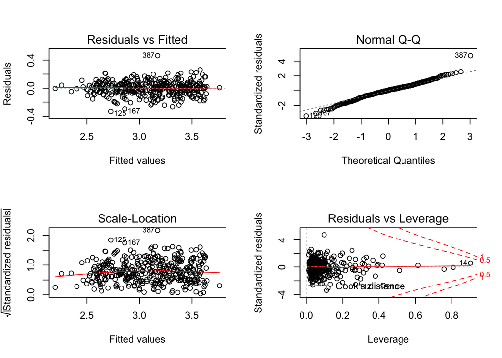

```r
plot(fit4)
```

The residual graph has slightly less heteroscedasticity. Our model also has a better R-squared value. However, I am afraid with so many generated features, this model might overfit.

The previous model (fit4), has many features and as expected, diluted the p-value. There were many collinear features. I want to use the least amount of predictors as possible so after fooling around with the data, I noticed persistent correlation in many of my models, especially displacement:weight and cylinders:horsepower:acceleration.

```r
fit5=lm(log(mpg) ~. + displacement:weight + cylinders:horsepower:acceleration - name, data = Auto)
par(mfrow=c(2,2))
summary(fit5)
```

```
##
## Call:
## lm(formula = log(mpg) ~ . + displacement:weight + cylinders:horsepower:acceleration -
##     name, data = Auto)
##
## Residuals:
##      Min       1Q   Median       3Q      Max
## -0.39749 -0.07006  0.00268  0.06024  0.40179
##
## Coefficients:
##                                     Estimate Std. Error t value Pr(>|t|)
## (Intercept)                        1.563e+00  2.075e-01   7.535 3.57e-13
## cylinders                          4.490e-02  1.914e-02   2.346 0.019493
## displacement                      -2.250e-03  4.557e-04  -4.938 1.18e-06
## horsepower                         3.916e-04  7.684e-04   0.510 0.610580
## weight                            -3.439e-04  2.709e-05 -12.695  < 2e-16
## acceleration                       1.152e-02  4.870e-03   2.366 0.018468
## year                               3.089e-02  1.715e-03  18.020  < 2e-16
## origin                             1.414e-02  9.946e-03   1.422 0.155958
## displacement:weight                6.381e-07  8.720e-08   7.317 1.51e-12
## cylinders:horsepower:acceleration -2.897e-05  7.846e-06  -3.693 0.000254
##
## (Intercept)                       ***
## cylinders                         *
## displacement                      ***
## horsepower
## weight                            ***
## acceleration                      *
## year                              ***
## origin
## displacement:weight               ***
## cylinders:horsepower:acceleration ***
## ---
## Signif. codes:  0 '***' 0.001 '**' 0.01 '*' 0.05 '.' 0.1 ' ' 1
##
## Residual standard error: 0.1113 on 382 degrees of freedom
## Multiple R-squared:  0.8953, Adjusted R-squared:  0.8928
## F-statistic:   363 on 9 and 382 DF,  p-value: < 2.2e-16
```

Notice that origin and horsepower contributes little to reducing variance. These predictors, if removed will have little impact on R-squared

```r
fit6=lm(log(mpg) ~. + displacement:weight + cylinders:horsepower:acceleration - name - horsepower - origin, data = Auto)
par(mfrow=c(2,2))
summary(fit6)
```

```
##
## Call:
## lm(formula = log(mpg) ~ . + displacement:weight + cylinders:horsepower:acceleration -
##     name - horsepower - origin, data = Auto)
##
## Residuals:
##      Min       1Q   Median       3Q      Max
## -0.39221 -0.06873  0.00584  0.06144  0.40258
##
## Coefficients:
##                                     Estimate Std. Error t value Pr(>|t|)
## (Intercept)                        1.711e+00  1.377e-01  12.422  < 2e-16
## cylinders                          3.998e-02  1.396e-02   2.864 0.004419
## displacement                      -2.440e-03  3.853e-04  -6.331 6.81e-10
## weight                            -3.529e-04  2.633e-05 -13.404  < 2e-16
## acceleration                       8.842e-03  2.639e-03   3.350 0.000887
## year                               3.074e-02  1.686e-03  18.231  < 2e-16
## displacement:weight                6.786e-07  8.175e-08   8.301 1.78e-15
## cylinders:horsepower:acceleration -2.536e-05  4.744e-06  -5.346 1.54e-07
##
## (Intercept)                       ***
## cylinders                         **
## displacement                      ***
## weight                            ***
## acceleration                      ***
## year                              ***
## displacement:weight               ***
## cylinders:horsepower:acceleration ***
## ---
## Signif. codes:  0 '***' 0.001 '**' 0.01 '*' 0.05 '.' 0.1 ' ' 1
##
## Residual standard error: 0.1114 on 384 degrees of freedom
## Multiple R-squared:  0.8946, Adjusted R-squared:  0.8926
## F-statistic: 465.5 on 7 and 384 DF,  p-value: < 2.2e-16
```

So with the removal of origin and horsepower, we kept relatively the same R-squared and simplified our model. Let’s examine the variance inflation factor for further collinearity in our model

```r
vif(fit6)
```

```
##                         cylinders                      displacement
##                         17.863050                         51.216542
##                            weight                      acceleration
##                         15.755739                          1.669884
##                              year               displacement:weight
##                          1.215453                         57.726733
## cylinders:horsepower:acceleration
##                         16.865460
```

There is high VIF values for displacement:weight and displacement. Perhaps these two predictors are still too closely related. Let’s try removing displacement to reduce redundant predictors

```r
fit7=lm(log(mpg) ~. + displacement:weight + cylinders:horsepower:acceleration - name - horsepower - origin - displacement, data = Auto)
par(mfrow=c(2,2))
summary(fit7)
```

```
##
## Call:
## lm(formula = log(mpg) ~ . + displacement:weight + cylinders:horsepower:acceleration -
##     name - horsepower - origin - displacement, data = Auto)
##
## Residuals:
##      Min       1Q   Median       3Q      Max
## -0.39514 -0.07047  0.00619  0.06658  0.35469
##
## Coefficients:
##                                     Estimate Std. Error t value Pr(>|t|)
## (Intercept)                        1.641e+00  1.441e-01  11.390  < 2e-16
## cylinders                         -1.114e-02  1.195e-02  -0.932 0.351842
## weight                            -3.381e-04  2.752e-05 -12.283  < 2e-16
## acceleration                       9.638e-03  2.767e-03   3.484 0.000552
## year                               3.103e-02  1.769e-03  17.538  < 2e-16
## displacement:weight                2.657e-07  5.172e-08   5.137 4.45e-07
## cylinders:horsepower:acceleration -1.757e-05  4.809e-06  -3.655 0.000293
##
## (Intercept)                       ***
## cylinders
## weight                            ***
## acceleration                      ***
## year                              ***
## displacement:weight               ***
## cylinders:horsepower:acceleration ***
## ---
## Signif. codes:  0 '***' 0.001 '**' 0.01 '*' 0.05 '.' 0.1 ' ' 1
##
## Residual standard error: 0.1169 on 385 degrees of freedom
## Multiple R-squared:  0.8836, Adjusted R-squared:  0.8818
## F-statistic: 486.9 on 6 and 385 DF,  p-value: < 2.2e-16
```

```r
vif(fit7)
```

```
##                         cylinders                            weight
##                         11.887610                         15.630759
##                      acceleration                              year
##                          1.666095                          1.214585
##               displacement:weight cylinders:horsepower:acceleration
##                         20.979660                         15.731256
```

After removing the displacement predictor, there is a significant decrease in VIF values but also decrease in our R-squared value from 0.8946 to 0.8836. I think this is a significant decrease so I will stick with model fit6.

## Excercise 10

### 10.a

```r
csfit = lm(Sales ~ Price + Urban + US, data=Carseats)
summary(csfit)
```

```
##
## Call:
## lm(formula = Sales ~ Price + Urban + US, data = Carseats)
##
## Residuals:
##     Min      1Q  Median      3Q     Max
## -6.9206 -1.6220 -0.0564  1.5786  7.0581
##
## Coefficients:
##              Estimate Std. Error t value Pr(>|t|)
## (Intercept) 13.043469   0.651012  20.036  < 2e-16 ***
## Price       -0.054459   0.005242 -10.389  < 2e-16 ***
## UrbanYes    -0.021916   0.271650  -0.081    0.936
## USYes        1.200573   0.259042   4.635 4.86e-06 ***
## ---
## Signif. codes:  0 '***' 0.001 '**' 0.01 '*' 0.05 '.' 0.1 ' ' 1
##
## Residual standard error: 2.472 on 396 degrees of freedom
## Multiple R-squared:  0.2393, Adjusted R-squared:  0.2335
## F-statistic: 41.52 on 3 and 396 DF,  p-value: < 2.2e-16
```

Price: Statistically important bc low p-value Urban: not important US: Statistically important when located in US bc low p-value

### 10.c

y_hat = B_0 + B_1 * Price + B_2 * UrbanYes + B_3 * USYes

### 10.d

I can reject the null hypothesis for predictors Price & US

### 10.e